# Lab 3

Brian Sayre, Desmond Orton, Caitlin Fordell

3/5/2021

## Setup

```r
library(dplyr)
library(tidyverse)
```

```r
library(ggplot2)
data <- readxl::read_xls('./GSS.xls')
str(data)
```

```
## tibble [64,814 x 10] (S3: tbl_df/tbl/data.frame)
##  $ Gss year for this respondent    : num [1:64814] 1972 1972 1972 1972 1972 ...
##  $ General happiness               : chr [1:64814] "Not too happy" "Not too happy" "Pretty happy" "Not too happy" ...
##  $ Political party affiliation     : chr [1:64814] "Ind,near dem" "Not str democrat" "Independent" "Not str democrat" ...
##  $ Total family income             : chr [1:64814] "Not applicable" "Not applicable" "Not applicable" "Not applicable" ...
##  $ Race of respondent              : chr [1:64814] "White" "White" "White" "White" ...
##  $ Respondents sex                 : chr [1:64814] "Female" "Male" "Female" "Female" ...
##  $ Highest year of school completed: chr [1:64814] "16" "10" "12" "17" ...
##  $ Marital status                  : chr [1:64814] "Never married" "Married" "Married" "Married" ...
##  $ Respondent id number            : num [1:64814] 1 2 3 4 5 6 7 8 9 10 ...
##  $ Ballot used for interview       : chr [1:64814] "Not applicable" "Not applicable" "Not applicable" "Not applicable" ...
```

```r
df <- data.frame(
  year=data$`Gss year for this respondent`,
  happy=data$`General happiness`,
  party=data$`Political party affiliation`,
  income=data$`Total family income`,
  race=data$`Race of respondent`,
  sex=data$`Respondents sex`,
  school=data$`Highest year of school completed`,
  mstatus=data$`Marital status`,
  id=data$`Respondent id number`,
  ballot=data$`Ballot used for interview`)
str(df)
```

```
## 'data.frame':    64814 obs. of  10 variables:
##  $ year   : num  1972 1972 1972 1972 1972 ...
##  $ happy  : chr  "Not too happy" "Not too happy" "Pretty happy" "Not too happy" ...
##  $ party  : chr  "Ind,near dem" "Not str democrat" "Independent" "Not str democrat" ...
##  $ income : chr  "Not applicable" "Not applicable" "Not applicable" "Not applicable" ...
##  $ race   : chr  "White" "White" "White" "White" ...
##  $ sex    : chr  "Female" "Male" "Female" "Female" ...
##  $ school : chr  "16" "10" "12" "17" ...
##  $ mstatus: chr  "Never married" "Married" "Married" "Married" ...
##  $ id     : num  1 2 3 4 5 6 7 8 9 10 ...
##  $ ballot : chr  "Not applicable" "Not applicable" "Not applicable" "Not applicable" ...
```

### Question 1

Average years of education for respondents with each marital status.

```r
q1df <- as.data.frame(df)
q1df <- filter(q1df, school != 'No answer' & school != "Don't know" & !is.na(school) & school != "NA" )
unique(q1df$school)
```

```
##  [1] "16" "10" "12" "17" "14" "13" "6"  "9"  "8"  "11" "7"  "15" "20" "18" "3"
## [16] "2"  "4"  "5"  "19" "1"  "0"
```

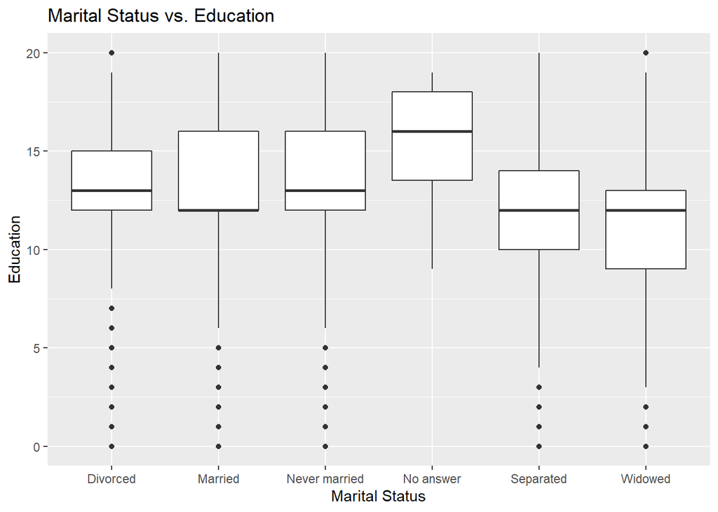

```r
q1df$school <- as.numeric(q1df$school)
ggplot(q1df, aes(y=school, x=mstatus), fill=school) + geom_boxplot()+xlab("Marital Status")+ylab("Education")+ggtitle("Marital Status vs. Education")
```

```r
q1df %>%
  group_by(mstatus) %>%
  summarize(
    mean_rate = mean(school, na.rm=TRUE),
    sd_rate = sd(school, na.rm=TRUE),
    nrows = n()
  )
```

```
## # A tibble: 6 x 4
##   mstatus       mean_rate sd_rate nrows
## * <chr>             <dbl>   <dbl> <int>
## 1 Divorced           13.1    2.91  8363
## 2 Married            13.0    3.19 34053
## 3 Never married      13.4    2.85 13801
## 4 No answer          15.5    2.84    23
## 5 Separated          11.9    3.28  2233
## 6 Widowed            11.2    3.49  6164
```

I chose to display the data as a boxplot for each marriage status. I chose this to show as mush information about the education for each status as possible. We can see that the ones with no answer seem to have the highest mean education which is something I did not expect. We also can see the rest have around the same mean, but a difference in most of their interquartile ranges. Divorced, married and never married seem to have a higher IQR than separated and widowed.

### Question 2

Creating a data frame for better educated respondents for each marital status

```r
q2df <- q1df %>%
  group_by(mstatus) %>%
  filter(school > mean(school))
str(q2df)
```

```
## tibble [30,714 x 10] (S3: grouped_df/tbl_df/tbl/data.frame)
##  $ year   : num [1:30714] 1972 1972 1972 1972 1972 ...
##  $ happy  : chr [1:30714] "Not too happy" "Not too happy" "Pretty happy" "Not too happy" ...
##  $ party  : chr [1:30714] "Ind,near dem" "Not str democrat" "Ind,near dem" "Ind,near dem" ...
##  $ income : chr [1:30714] "Not applicable" "Not applicable" "Not applicable" "Not applicable" ...
##  $ race   : chr [1:30714] "White" "White" "White" "White" ...
##  $ sex    : chr [1:30714] "Female" "Female" "Male" "Male" ...
##  $ school : num [1:30714] 16 17 14 16 13 14 14 17 14 13 ...
##  $ mstatus: chr [1:30714] "Never married" "Married" "Never married" "Never married" ...
##  $ id     : num [1:30714] 1 4 6 8 11 16 17 19 20 23 ...
##  $ ballot : chr [1:30714] "Not applicable" "Not applicable" "Not applicable" "Not applicable" ...
##  - attr(*, "groups")= tibble [6 x 2] (S3: tbl_df/tbl/data.frame)
##   ..$ mstatus: chr [1:6] "Divorced" "Married" "Never married" "No answer" ...
##   ..$ .rows  : list<int> [1:6]
##   .. ..$ : int [1:3414] 23 41 56 77 166 208 250 304 334 378 ...
##   .. ..$ : int [1:16040] 2 5 6 7 8 10 11 12 14 15 ...
##   .. ..$ : int [1:6250] 1 3 4 9 13 17 21 22 25 28 ...
##   .. ..$ : int [1:14] 9288 10465 11676 13143 22339 22935 22950 22986 23943 26304 ...
##   .. ..$ : int [1:1458] 43 44 51 89 107 108 128 141 156 221 ...
##   .. ..$ : int [1:3538] 47 76 81 87 99 103 113 115 122 125 ...
##   .. ..@ ptype: int(0)
##   ..- attr(*, ".drop")= logi TRUE
```

### Question 3

How is happiness related to marital status?

```r
df2 <- as.data.frame(df)
str(df2)
```

```
## 'data.frame':    64814 obs. of  10 variables:
##  $ year   : num  1972 1972 1972 1972 1972 ...
##  $ happy  : chr  "Not too happy" "Not too happy" "Pretty happy" "Not too happy" ...
##  $ party  : chr  "Ind,near dem" "Not str democrat" "Independent" "Not str democrat" ...
##  $ income : chr  "Not applicable" "Not applicable" "Not applicable" "Not applicable" ...
##  $ race   : chr  "White" "White" "White" "White" ...
##  $ sex    : chr  "Female" "Male" "Female" "Female" ...
##  $ school : chr  "16" "10" "12" "17" ...
##  $ mstatus: chr  "Never married" "Married" "Married" "Married" ...
##  $ id     : num  1 2 3 4 5 6 7 8 9 10 ...
##  $ ballot : chr  "Not applicable" "Not applicable" "Not applicable" "Not applicable" ...
```

```r
happy_df <- df2 %>%
  group_by(mstatus) %>%
  filter(happy=="Pretty happy" | happy=="Very happy") %>%
  filter(mstatus!="No answer")

unhappy_df <- df2 %>%
  group_by(mstatus) %>%
  filter(happy=="Not too happy") %>%
  filter(mstatus!="No answer")

unhappy_table <- unhappy_df %>%
  group_by(mstatus) %>%
  summarize(
    Total_Unhappy=n()
  )
unhappy_table
```

```
## # A tibble: 5 x 2
##   mstatus       Total_Unhappy
## * <chr>                 <int>
## 1 Divorced               1450
## 2 Married                2431
## 3 Never married          2055
## 4 Separated               588
## 5 Widowed                1140
```

```r
happy_table <- happy_df %>%
  group_by(mstatus) %>%
  summarize(
    Total_Happy=n()
  )
happy_table
```

```
## # A tibble: 5 x 2
##   mstatus       Total_Happy
## * <chr>               <int>
## 1 Divorced             6180
## 2 Married             29342
## 3 Never married       10686
## 4 Separated            1487
## 5 Widowed              4675
```

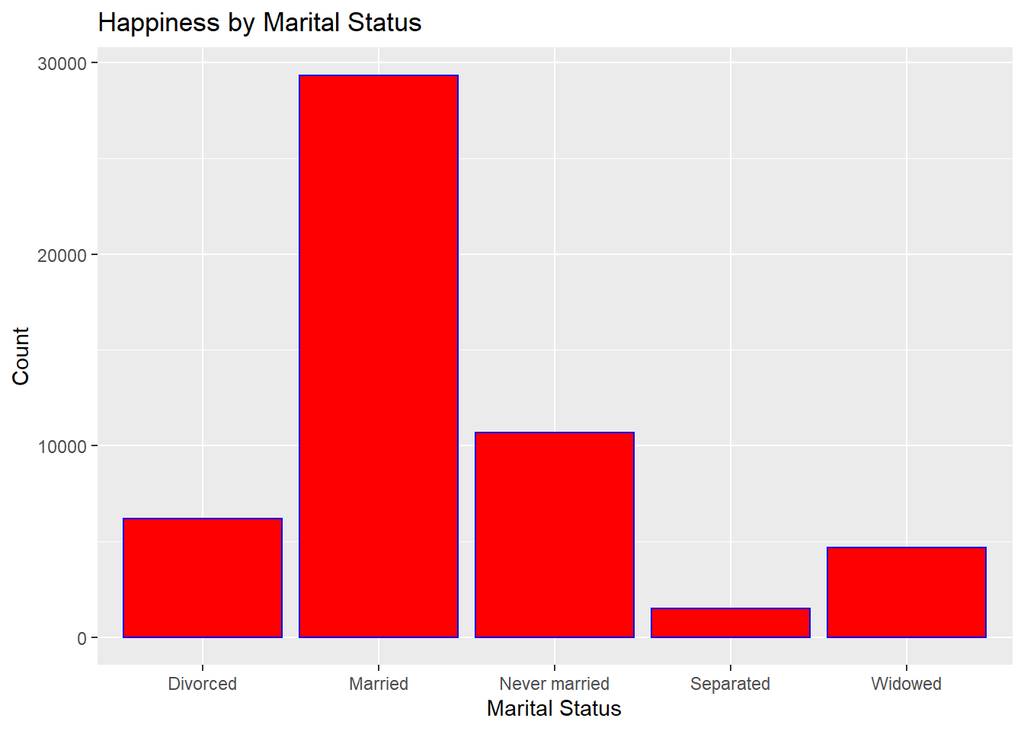

```r
ggplot(happy_df, aes(x=mstatus)) + geom_bar(color="blue", fill="red") + ggtitle("Happiness by Marital Status")+xlab("Marital Status")+ylab("Count")
```

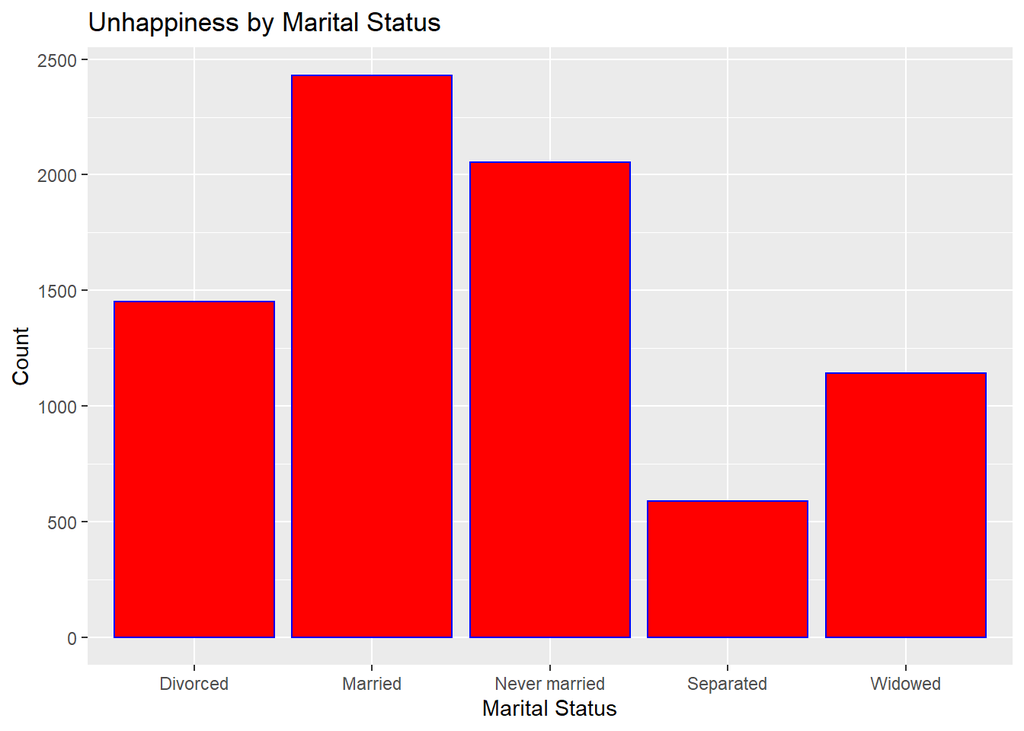

```r
ggplot(unhappy_df, aes(x=mstatus)) + geom_bar(color="blue", fill="red")  + ggtitle("Unhappiness by Marital Status")+xlab("Marital Status")+ylab("Count")
```

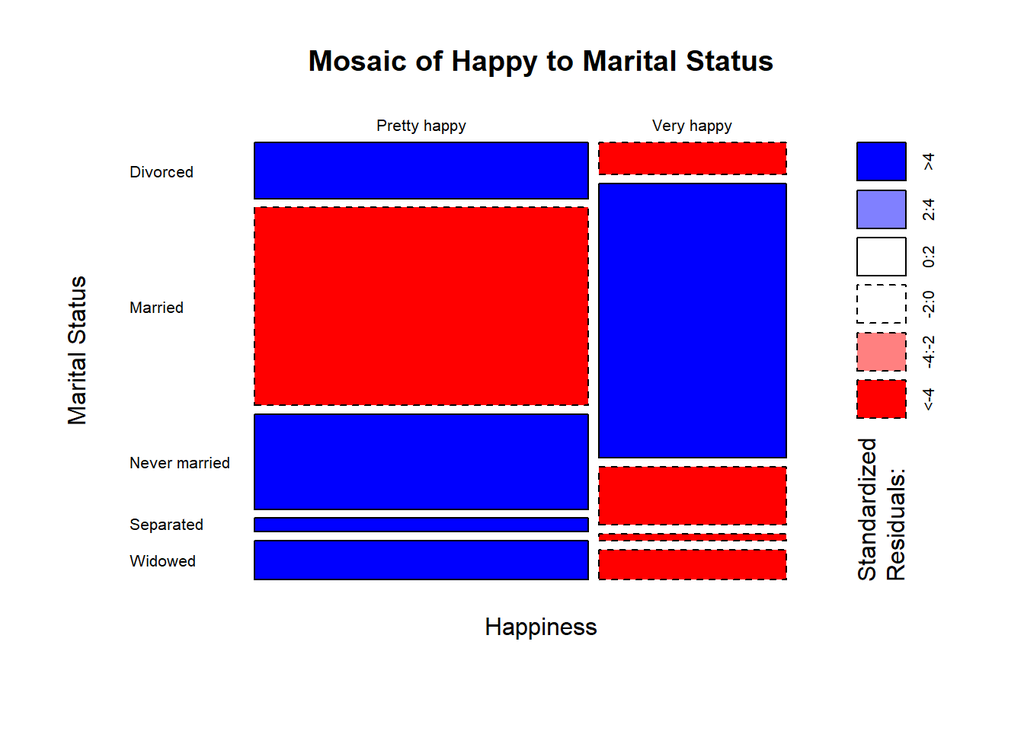

```r
mosaicplot(happy_df$happy~happy_df$mstatus, shade=TRUE, las=1, main="Mosaic of Happy to Marital Status", xlab="Happiness", ylab="Marital Status")
```

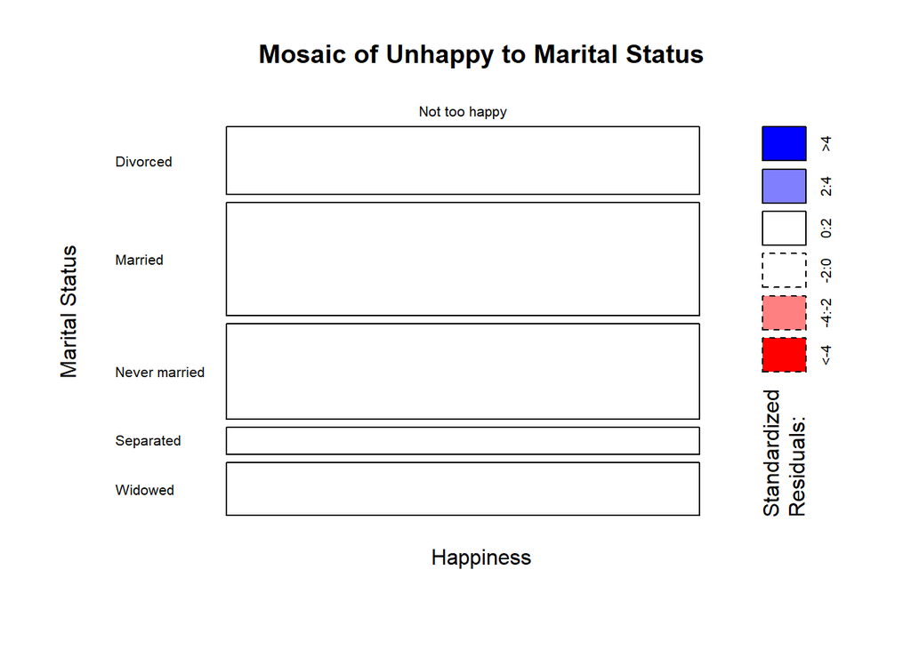

```r
mosaicplot(unhappy_df$happy~unhappy_df$mstatus, shade=TRUE, las=1, main="Mosaic of Unhappy to Marital Status", xlab="Happiness", ylab="Marital Status")
```

### Question 4

Does party affiliation affect the relationship between happiness and marital status?

```r
unique(happy_df$party)
```

```
##  [1] "Independent"        "Strong democrat"    "Ind,near dem"
##  [4] "Not str republican" "Ind,near rep"       "Not str democrat"
##  [7] "Strong republican"  "Other party"        "No answer"
## [10] "Don't know"
```

```r
happy_indep_df <- happy_df %>%
  group_by(mstatus) %>%
  filter(party=="Independent" | party=="Ind,near rep" | party=="Ind,near dem")
happy_indep_df
```

```
## # A tibble: 18,564 x 10
## # Groups:   mstatus [5]
##     year happy    party    income    race  sex   school mstatus      id ballot
##    <dbl> <chr>    <chr>    <chr>     <chr> <chr> <chr>  <chr>     <dbl> <chr>
##  1  1972 Pretty ~ Indepen~ Not appl~ White Fema~ 12     Married       3 Not app~
##  2  1972 Pretty ~ Ind,nea~ Not appl~ White Male  14     Never ma~     6 Not app~
##  3  1972 Very ha~ Ind,nea~ Not appl~ White Male  14     Married      17 Not app~
##  4  1972 Very ha~ Ind,nea~ Not appl~ White Fema~ 8      Married      18 Not app~
##  5  1972 Very ha~ Ind,nea~ Not appl~ White Fema~ 17     Married      19 Not app~
##  6  1972 Very ha~ Ind,nea~ Not appl~ White Fema~ 14     Never ma~    20 Not app~
##  7  1972 Very ha~ Ind,nea~ Not appl~ White Male  12     Married      21 Not app~
##  8  1972 Very ha~ Ind,nea~ Not appl~ White Male  13     Married      23 Not app~
##  9  1972 Very ha~ Ind,nea~ Not appl~ White Fema~ 12     Married      24 Not app~
## 10  1972 Very ha~ Ind,nea~ Not appl~ White Fema~ 12     Married      26 Not app~
## # ... with 18,554 more rows
```

```r
ti1 <- happy_indep_df %>%
  summarize(
    Total_Happy_Indep=n()
  )
ti1
```

```
## # A tibble: 5 x 2
##   mstatus       Total_Happy_Indep
##   <chr>                     <int>
## 1 Divorced                   2377
## 2 Married                    9962
## 3 Never married              4475
## 4 Separated                   582
## 5 Widowed                    1168
```

```r
unhappy_indep_df <- unhappy_df %>%
  group_by(mstatus) %>%
  filter(party=="Independent" | party=="Ind,near rep" | party=="Ind,near dem")
unhappy_indep_df
```

```
## # A tibble: 3,022 x 10
## # Groups:   mstatus [5]
##     year happy    party    income    race  sex   school mstatus      id ballot
##    <dbl> <chr>    <chr>    <chr>     <chr> <chr> <chr>  <chr>     <dbl> <chr>
##  1  1972 Not too~ Ind,nea~ Not appl~ White Fema~ 16     Never ma~     1 Not app~
##  2  1972 Not too~ Ind,nea~ Not appl~ White Male  13     Divorced      7 Not app~
##  3  1972 Not too~ Ind,nea~ Not appl~ White Male  16     Never ma~     8 Not app~
##  4  1972 Not too~ Indepen~ Not appl~ White Fema~ 11     Married      74 Not app~
##  5  1972 Not too~ Indepen~ Not appl~ Black Fema~ 11     Separated   118 Not app~
##  6  1972 Not too~ Ind,nea~ Not appl~ White Fema~ 12     Married     128 Not app~
##  7  1972 Not too~ Ind,nea~ Not appl~ White Male  6      Married     131 Not app~
##  8  1972 Not too~ Indepen~ Not appl~ White Male  14     Married     143 Not app~
##  9  1972 Not too~ Ind,nea~ Not appl~ White Male  15     Married     191 Not app~
## 10  1972 Not too~ Ind,nea~ Not appl~ White Fema~ 9      Married     246 Not app~
## # ... with 3,012 more rows
```

```r
ti2 <- unhappy_indep_df %>%
  summarize(
    Total_Unhappy_Indep=n()
  )
ti2
```

```
## # A tibble: 5 x 2
##   mstatus       Total_Unhappy_Indep
##   <chr>                       <int>
## 1 Divorced                      569
## 2 Married                       931
## 3 Never married                 967
## 4 Separated                     243
## 5 Widowed                       312
```

```r
happy_rep_df <- happy_df %>%
  group_by(mstatus) %>%
  filter(party=="Strong republican" | party=="Not str republican")
t1 <- happy_rep_df %>%
  summarize(
    Total_Happy_Rep=n()
  )
t1
```

```
## # A tibble: 5 x 2
##   mstatus       Total_Happy_Rep
##   <chr>                   <int>
## 1 Divorced                 1381
## 2 Married                  8661
## 3 Never married            2116
## 4 Separated                 243
## 5 Widowed                  1288
```

```r
unhappy_rep_df <- unhappy_df %>%
  group_by(mstatus) %>%
  filter(party=="Strong republican" | party=="Not str republican")
t2 <- unhappy_rep_df %>%
  summarize(
    Total_Unhappy_Rep=n()
  )
t2
```

```
## # A tibble: 5 x 2
##   mstatus       Total_Unhappy_Rep
##   <chr>                     <int>
## 1 Divorced                    249
## 2 Married                     452
## 3 Never married               262
## 4 Separated                    85
## 5 Widowed                     262
```

```r
happy_dem_df <- happy_df %>%
  group_by(mstatus) %>%
  filter(party=="Strong democrat" | party=="Not str democrat")
t3 <- happy_dem_df %>%
  summarize(
    Total_Happy_Rep=n()
  )
t3
```

```
## # A tibble: 5 x 2
##   mstatus       Total_Happy_Rep
##   <chr>                   <int>
## 1 Divorced                 2266
## 2 Married                 10120
## 3 Never married            3828
## 4 Separated                 633
## 5 Widowed                  2133
```

```r
unhappy_dem_df <- unhappy_df %>%
  group_by(mstatus) %>%
  filter(party=="Strong democrat" | party=="Not str democrat")
t4 <- unhappy_dem_df%>%
  summarize(
    Total_Unhappy_Rep=n()
  )
t4
```

```
## # A tibble: 5 x 2
##   mstatus       Total_Unhappy_Rep
##   <chr>                     <int>
## 1 Divorced                    586
## 2 Married                     983
## 3 Never married               751
## 4 Separated                   251
## 5 Widowed                     542
```

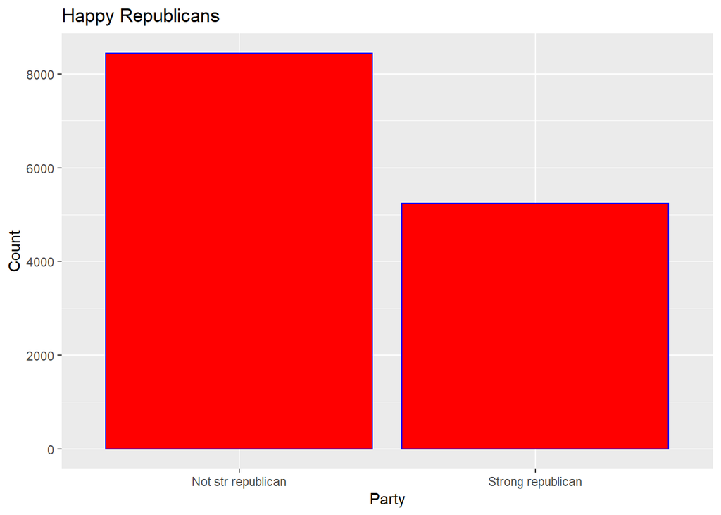

```r
ggplot(happy_rep_df, aes(x=party)) + geom_bar(color="blue", fill="red") + ggtitle("Happy Republicans")+xlab("Party")+ylab("Count")
```

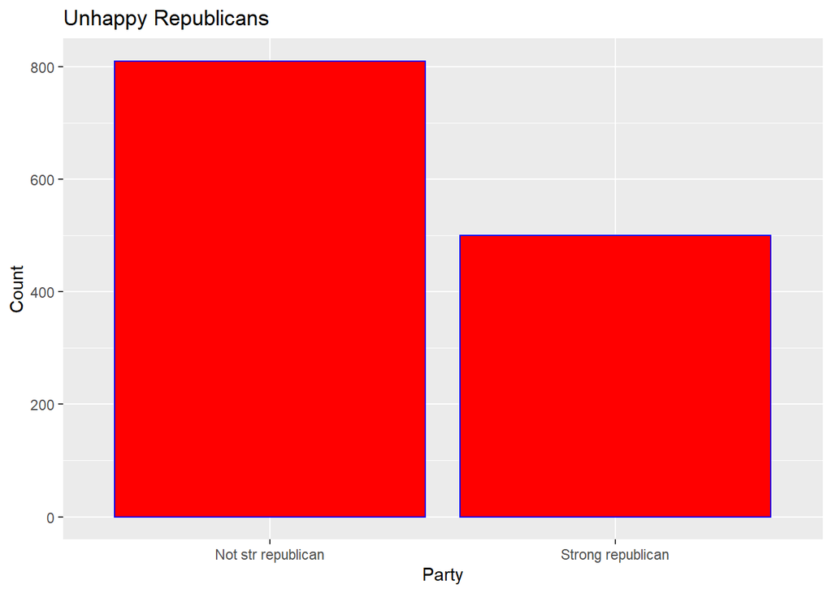

```r
ggplot(unhappy_rep_df, aes(x=party)) + geom_bar(color="blue", fill="red") + ggtitle("Unhappy Republicans")+xlab("Party")+ylab("Count")
```

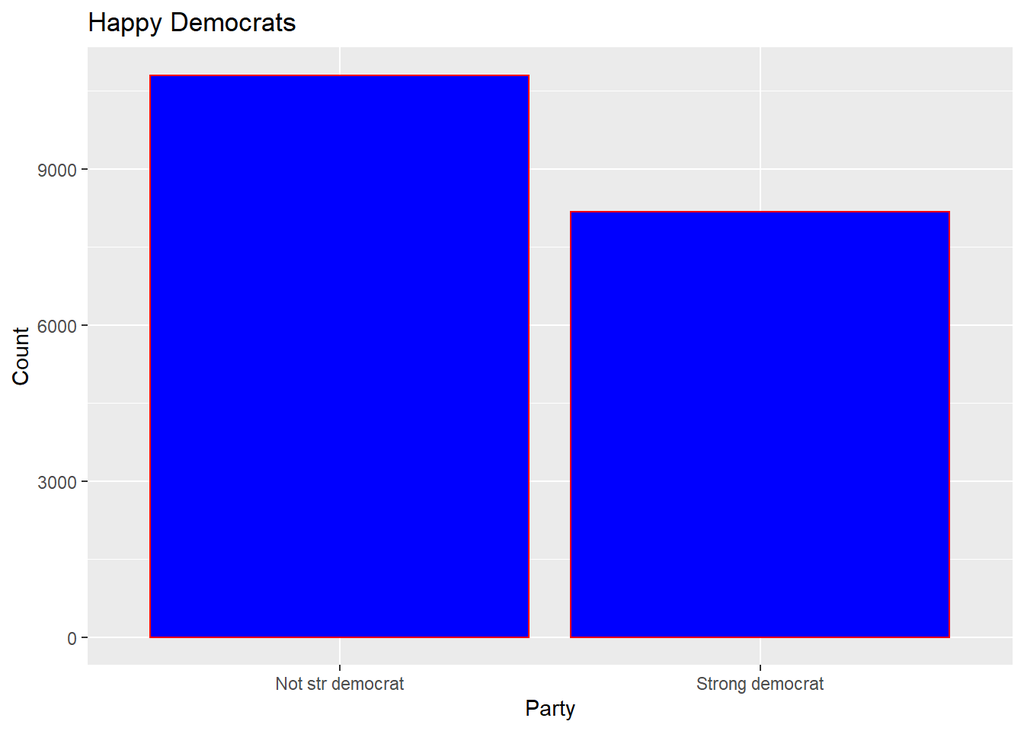

```r
ggplot(happy_dem_df, aes(x=party)) + geom_bar(color="red", fill="blue") + ggtitle("Happy Democrats")+xlab("Party")+ylab("Count")
```

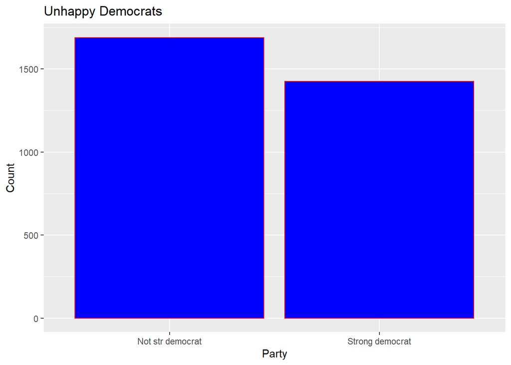

```r
ggplot(unhappy_dem_df, aes(x=party)) + geom_bar(color="red", fill="blue") + ggtitle("Unhappy Democrats")+xlab("Party")+ylab("Count")
```

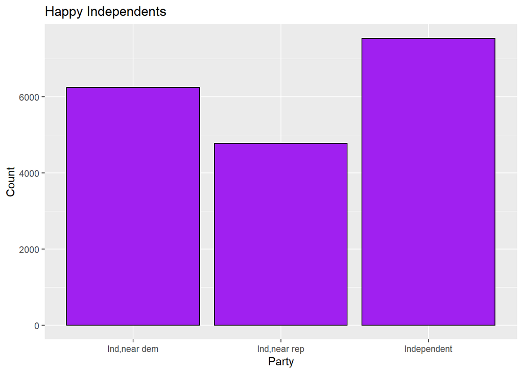

```r
ggplot(happy_indep_df, aes(x=party)) + geom_bar(color="black", fill="purple") + ggtitle("Happy Independents")+xlab("Party")+ylab("Count")
```

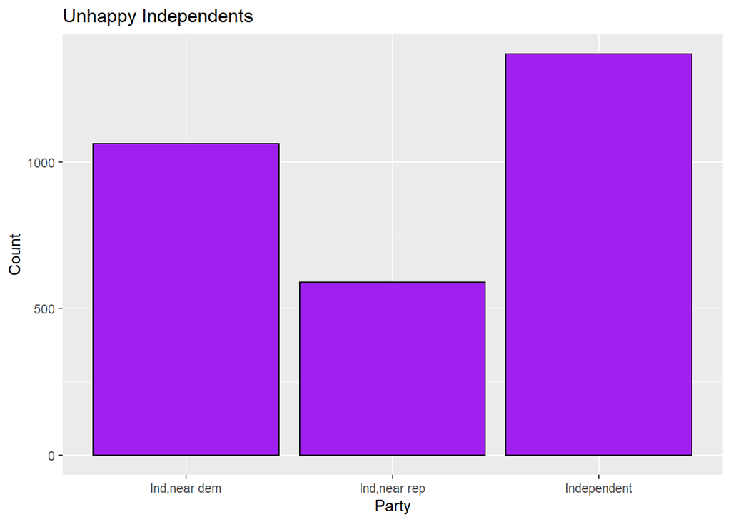

```r
ggplot(unhappy_indep_df, aes(x=party)) + geom_bar(color="black", fill="purple") + ggtitle("Unhappy Independents")+xlab("Party")+ylab("Count")
```

## Question 5

What is the relationship between martial status and education?

```r
##creating data frame for Q5
q5df <- as.data.frame(df)
q5df <- filter(q5df, school != 'No answer' & school != "Don't know" & !is.na(school) & school != "NA" )
unique(q5df$school)
```

```
##  [1] "16" "10" "12" "17" "14" "13" "6"  "9"  "8"  "11" "7"  "15" "20" "18" "3"
## [16] "2"  "4"  "5"  "19" "1"  "0"
```

```r
q5df$school <- as.numeric(q5df$school)
```

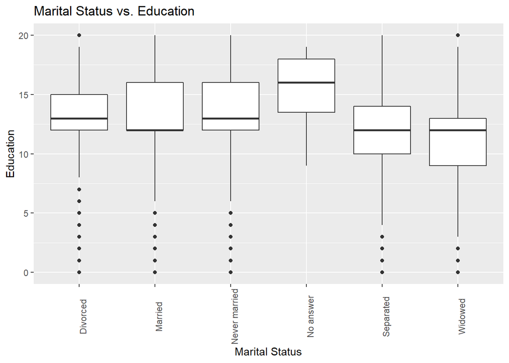

```r
##plot of marital status and education
ggplot(data=q5df, aes(x=mstatus,y=school))+geom_boxplot()+ggtitle("Marital Status vs. Education")+theme(axis.text.x = element_text(angle = 90))+xlab("Marital Status")+ylab("Education")
```

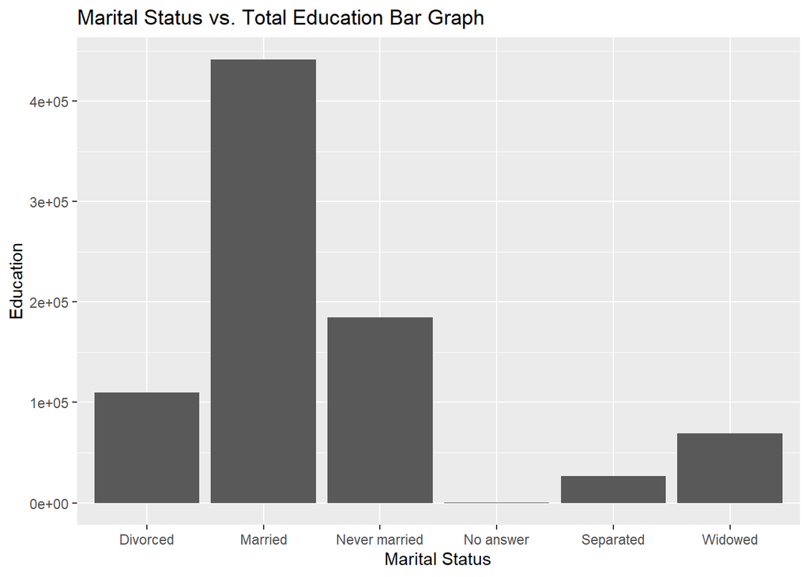

```r
ggplot(data=q5df, aes(x=mstatus, y=school))+geom_bar(stat = 'identity')+xlab("Marital Status")+ggtitle("Marital Status vs. Total Education Bar Graph")+ylab("Education")
```

Overall, the group of married people has the highest total amount of education, distantly followed by the never married group. Since this is the total education though, we can not tell if this is solely due to married people having more education or if there were just many more married people than other groups. This graph also shows that the total education of the No Answer group is much less than the total education for all other groups.

## Question 6A

What is the relationship between race and education?

```r
##exploring relationship between race and education
q6dfA <- select(df, race, school)
q6dfA <- filter(q6dfA, school != 'No answer' & school != "Don't know" & !is.na(school) & school != "NA" )
```

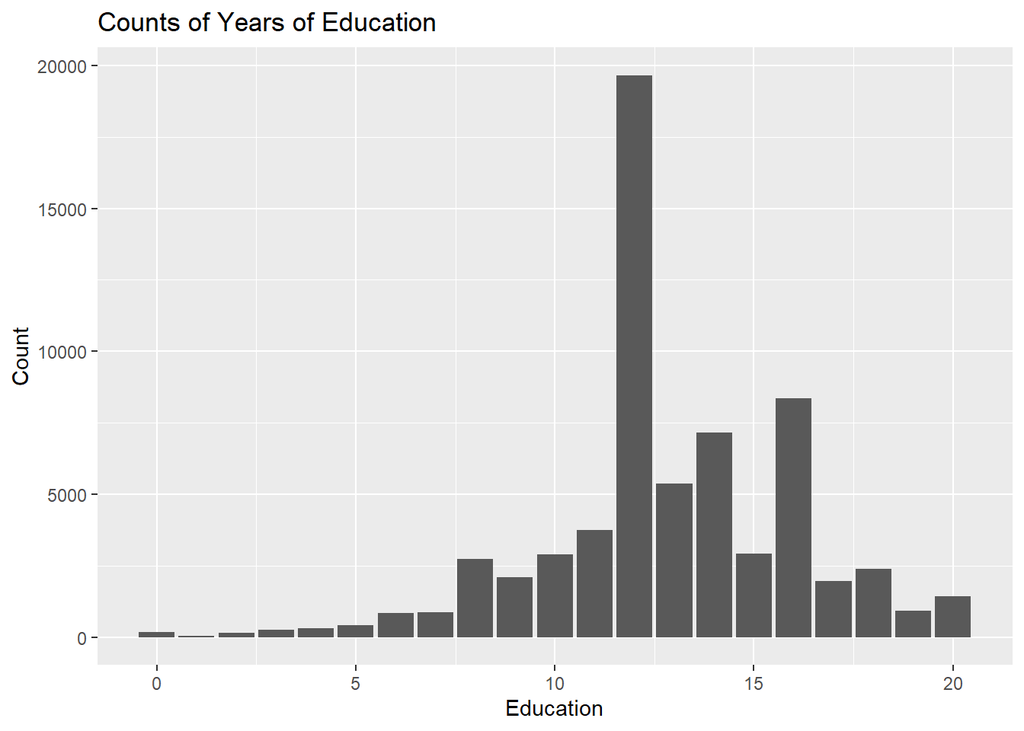

```r
##exploring school variable
q6dfA$school <- as.numeric(q6dfA$school)
ggplot(q6dfA, aes(x=school))+geom_bar()+xlab("Education")+ ylab("Count")+ggtitle("Counts of Years of Education")
```

The most common amount of education of respondents for the study was 12 years of school, which means that more respondents received a high school education than any other number of years of education. The data is skewed to the left with a center around 12 years of education.

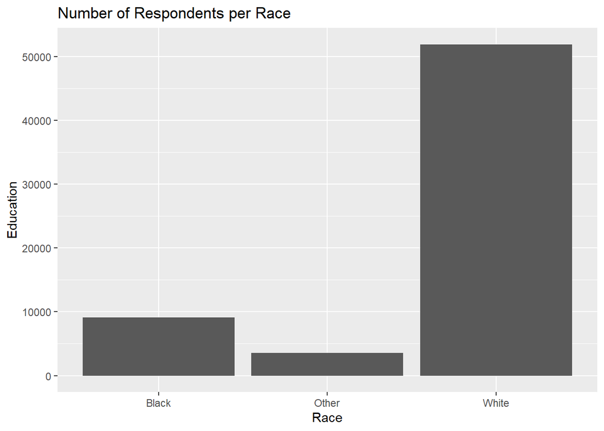

```r
##exploring race variable
ggplot(q6dfA, aes(x=race))+geom_bar()+xlab("Race")+ylab("Count")+ggtitle("Number of Respondents per Race")+xlab("Race")+ylab("Education")
```

There are approximately 5 times as many white respondents as the next largest category (black respondents). The majority of the data collected was from white-identifying people. There is still a sizeable amount of data for both the black and other people.

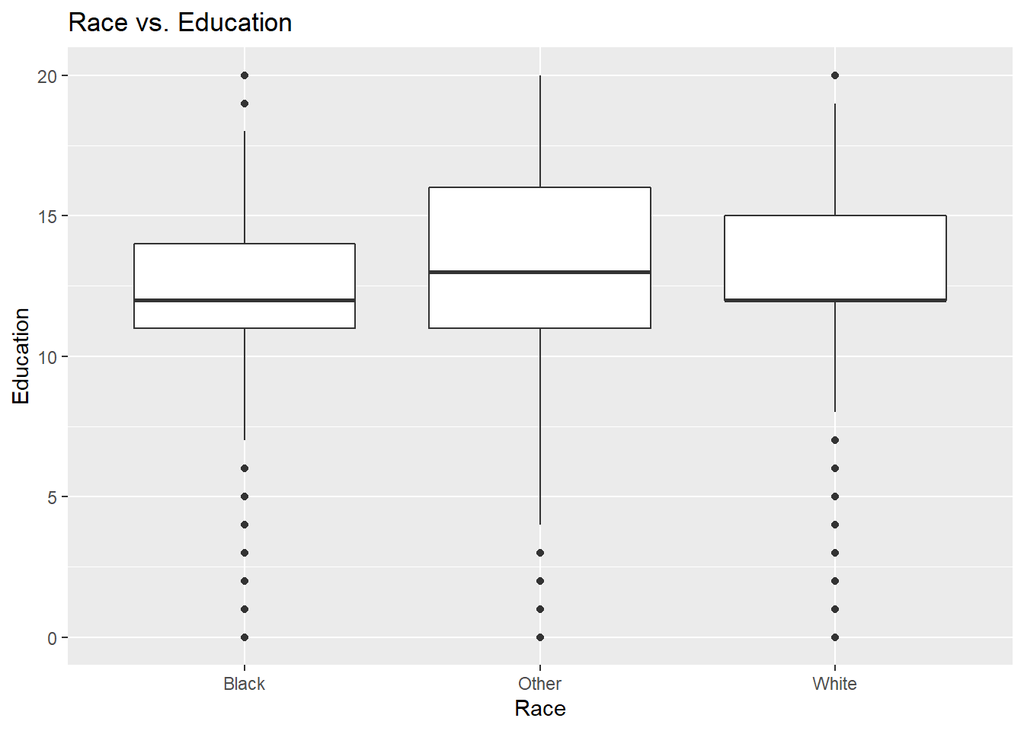

```r
##exploring the relationship between race and school
ggplot(data=q6dfA, aes(x=race, y=school))+geom_boxplot()+ggtitle("Race vs. Education")+xlab("Race")+ylab("Education")
```

The median years of education for both black and white people is about 12 years while the median years of education for the other races is 13 years. Overall, black people tended to have lower education than white people and the other races had the widest range. This could be because the other category includes other races like latino and asian.

### Question 6b

Does income affect your overall happiness?

```r
q6df <- select(df,happy, income)
q6df <- filter(q6df, happy != "No answer" & happy != "Don't know" & happy != "Not applicable")
q6df <- filter(q6df, income != "No answer" & income != "Don't know" & income != "Not applicable" & income != "Refused")
q6df$happyNum <- recode(q6df$happy, "Not too happy" = 1, "Pretty happy" = 2, "Very happy" = 3)
q6df <- aggregate(q6df$happyNum, by=list(q6df$income), FUN=mean)
q6qf <- rename(q6df, Income = Group.1, happy = x)
ordered <- c("Lt $1000", "$1000 to 2999", "$3000 to 3999", "$4000 to 4999", "$5000 to 5999", "$6000 to 6999", "$7000 to 7999", "$8000 to 9999", "$10000 - 14999", "$15000 - 19999", "$20000 - 24999", "$25000 or more")
q6qf$Income <- factor(q6qf$Income, levels=ordered)
```

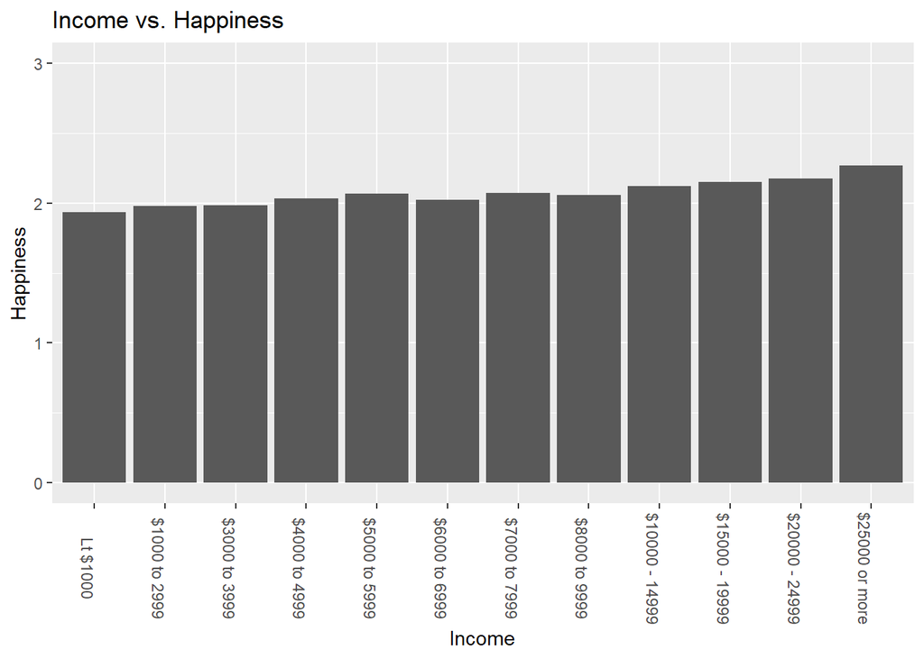

```r
ggplot(q6qf, aes(y=happy, x=Income)) + geom_bar(stat = "identity") + theme(axis.text.x = element_text(angle = -90))+ ylim(0, 3)+xlab("Income")+ylab("Happiness")+ggtitle("Income vs. Happiness")
```

```r
q6qf
```

```
##            Income    happy
## 1   $1000 to 2999 1.978056
## 2  $10000 - 14999 2.122988
## 3  $15000 - 19999 2.152606
## 4  $20000 - 24999 2.174376
## 5  $25000 or more 2.267714
## 6   $3000 to 3999 1.986190
## 7   $4000 to 4999 2.031943
## 8   $5000 to 5999 2.067098
## 9   $6000 to 6999 2.023438
## 10  $7000 to 7999 2.074044
## 11  $8000 to 9999 2.058151
## 12       Lt $1000 1.935440
```

The graph and data show that as a persons income increases the average happy rating increases. For the data, i used “Not too happy” = 1, “Pretty happy” = 2, “Very happy” = 3. This allowed me to run an average of each person for each income range. Although the happy slightly increase as income increases, we can see that they are all still right around a 2 average, which is pretty happy.